# Nutrient Solubility

Theoretical values corrected by pH

Anıl A. Tellbüscher

2022-07-06

# General

While comparing nutrient concentrations in aquaponic systems reported in literature with theoretical solubilities based on calculations using the solubility product constant $K_{sp}$, reported concentrations are approximately three orders of magnitude higher in case of Ca, Mg, Fe, Mn, Cu, Zn, and P. This could be due to the pH-dependence of the solubility of some salts.

For instance, orthophosphates undergo a number of acid-base reactions when introduced into aquatic systems. The chemical equilibria are depending on the system pH. In hydroponic systems, the recommended pH ranges around 6.0, while it is recommended to maintain a pH above 7.0 in aquaculture systems, including the aquaculture unit of on-demand coupled aquaponic systems. Considering the pH when calculating solubilities might thus lead to better, more precise results, because the pH is calculated on a logarithmic scale, which means that a change in the pH by one unit results in a change of the hydronium ion concentration by one order of magnitude.

# Preparation of data analysis

## 1.1 Load functions for species calculation

Some functions were written to calculate the true concentration of the precipitation-causing species in dependence of their total concentration in the system and the system pH. The acidity constants $K_{a}$ were taken from literature.

## 1.2 Load data

Rawdata is gathered by skimming relevant literature for data that can be used for a meta-analysis.

For correction of the solubilities by pH, the total concentrations $c_{T}$ of anions such as phosphorus in form of phosphates and sulfur in form of sulfates reported in the publications are recalculated based on the reported pH. The concentration of hydroxide is directly derived from the pH. Furthermore, the concentration of carbonate at the given pH is calculated, based on the assumption that the water is saturated with carbon dioxide. This yields the concentration of the dissolved species that is causing precipitation. Given this value and the solubility constants, the possible free concentrations of the cations that are forming precipitates with the mentioned anions is calculated.

# 2. pH-correction - 1st iteration

All concentrations are initially reported in mg/L.

```r
procdata <- empirical_data %>%

  # Rename columns
  rename(
    'NH4-N' = 'N.NH4_mgL',
    'NO2-N' = 'N.NO2_mgL',
    'NO3-N' = 'N.NO3_mgL',
    'PO4-P' = 'P.PO4_mgL',
    'K' = 'K_mgL',
    'Ca' = 'Ca_mgL',
    'Mg' = 'Mg_mgL',
    'SO4-S' = 'S.SO4_mgL',
    'B' = 'B_mgL',
    'Fe' = 'Fe_mgL',
    'Mn' = 'Mn_mgL',
    'Cu' = 'Cu_mgL',
    'Zn' = 'Zn_mgL',
    'Na' = 'Na_mgL',
    'Mo' = 'Mo_mgL',
    'Ni' = 'Ni_mgL'
    ) %>%

  select(-ends_with(c('const', 'belowLimit'))) %>%

  # Replace NAs by 0
  mutate_at(vars(`NH4-N`, `NO2-N`, `NO3-N`), tidyr::replace_na, 0) %>%

  mutate(
    # Calculate Total Inorganic Nitrogen by summing NH4, NO2 and NO3
    TIN = `NH4-N` + `NO2-N` + `NO3-N`,
    # Calculate [PO4]
    species_PO4_molL = calc_PO4(c_tot = `PO4-P`, pH = pH, form_P = "PO4-P", unit = "mg"),
    # Calculate [CO3]
    species_CO3_molL = calc_CO3(pH = pH),
    # Calculate [OH]
    species_OH_molL = calc_OH(pH = pH),
    # Calculate [SO4]
    species_SO4_molL = calc_SO4(c_tot = `SO4-S`, pH = pH, form_S = "SO4-S", unit = "mg")
    ) %>%
  print()
```

```
##      Reference_ID   Treatment_ID Include     source condition  days   pH
## 1   Blanchard2020            pH5     Yes waterTRANS   aerobic    NA 6.30
## 2   Blanchard2020          pH5.8     Yes waterTRANS   aerobic    NA 6.40
## 3   Blanchard2020          pH6.5     Yes waterTRANS   aerobic    NA 6.70
## 4   Blanchard2020            pH7     Yes waterTRANS   aerobic    NA 6.90
## 5      Cerozi2020         System     Yes waterTRANS   aerobic    NA 6.55
## 6     Delaide2018            AER     Yes waterREMIN   aerobic  42.0 6.54
## 7     Delaide2018            ANR     Yes waterREMIN anaerobic  42.0 6.65
## 8     Delaide2019             AP     Yes   waterRAS   aerobic    NA 7.85
## 9     Delaide2021             AE     Yes waterREMIN   aerobic  45.0 6.80
## 10     Goddek2016            AER     Yes waterREMIN   aerobic  35.0 8.40
## 11     Goddek2016            ANA     Yes waterREMIN anaerobic  35.0 8.50
## 12     Goddek2018 Uliege_aerobic     Yes waterREMIN   aerobic  40.0 7.20
## 13     Goddek2018            pH+     Yes waterREMIN anaerobic  40.0 7.40
## 14     Goddek2018            pH-     Yes waterREMIN anaerobic  40.0 7.40
```

[output cut: 225 more lines]

```r
# Import molar weight data
molarWeight <- read.csv2(file = 'data/molarWeight.csv')

#
procdata <- procdata %>%

  rename('S' = 'SO4-S', 'N' = 'TIN') %>%

  pivot_longer( # Convert into longtable
    cols = K:N,
    names_to = 'nutrient',
    values_to = 'concentration_mgL'
    ) %>%
  left_join(molarWeight, by = c('nutrient' = 'element')) %>%

  mutate(
    g_per_mol = as.numeric(g_per_mol), # Convert from character into numeric
    concentration_molL = concentration_mgL/(1e3 * g_per_mol) # Convert from mg/L into mol/L
    ) %>%

  select(-c(concentration_mgL, g_per_mol)) %>% # Remove unnecessary columns

  pivot_wider( # Convert into widetable
    names_from = 'nutrient',
    values_from = 'concentration_molL'
    ) %>%

  print()
```

```
## # A tibble: 47 × 30
##    Reference_ID  Treatment_ID Include source     condition  days    pH temp_degC
##    <chr>         <chr>        <chr>   <chr>      <chr>     <dbl> <dbl>     <dbl>
##  1 Blanchard2020 pH5          Yes     waterTRANS aerobic      NA  6.3       NA
##  2 Blanchard2020 pH5.8        Yes     waterTRANS aerobic      NA  6.4       NA
##  3 Blanchard2020 pH6.5        Yes     waterTRANS aerobic      NA  6.7       NA
##  4 Blanchard2020 pH7          Yes     waterTRANS aerobic      NA  6.9       NA
##  5 Cerozi2020    System       Yes     waterTRANS aerobic      NA  6.55      NA
##  6 Delaide2018   AER          Yes     waterREMIN aerobic      42  6.54      28
##  7 Delaide2018   ANR          Yes     waterREMIN anaerobic    42  6.65      28
##  8 Delaide2019   AP           Yes     waterRAS   aerobic      NA  7.85      NA
##  9 Delaide2021   AE           Yes     waterREMIN aerobic      45  6.8       20.5
## 10 Goddek2016    AER          Yes     waterREMIN aerobic      35  8.4       22.9
## # … with 37 more rows, and 22 more variables: EC_uScm <dbl>, NH4-N <dbl>,
## #   NO2-N <dbl>, NO3-N <dbl>, PO4-P <dbl>, species_PO4_molL <dbl>,
## #   species_CO3_molL <dbl>, species_OH_molL <dbl>, species_SO4_molL <dbl>,
## #   K <dbl>, Ca <dbl>, Mg <dbl>, S <dbl>, B <dbl>, Fe <dbl>, Mn <dbl>,
## #   Cu <dbl>, Zn <dbl>, Mo <dbl>, Ni <dbl>, Na <dbl>, N <dbl>
```

```r
procdata <- procdata %>%
  mutate(
    # CaCO3
    Ca_in_CaCO3 = solubility_data$Ks0[which(solubility_data$chemFormula == "CaCO3",)] / species_CO3_molL,
    Ca_found_greater_CaCO3 = Ca > Ca_in_CaCO3,
    CaCO3_diff = Ca - Ca_in_CaCO3,
    CaCO3_prop = Ca / Ca_in_CaCO3,

    # Ca(OH)2
    Ca_in_CaOH2 = solubility_data$Ks0[which(solubility_data$chemFormula == "Ca(OH)2",)] / species_OH_molL^2,
    Ca_found_greater_CaOH2 = Ca > Ca_in_CaOH2,
    CaOH2_diff = Ca - Ca_in_CaOH2,
    CaOH2_prop = Ca / Ca_in_CaOH2,

    # Ca3PO42
    Ca_in_Ca3PO42 = (solubility_data$Ks0[which(solubility_data$chemFormula == "Ca3(PO4)2",)] / species_PO4_molL^2)^(1/3),
    Ca_found_greater_Ca3PO42 = Ca > Ca_in_Ca3PO42,
    Ca3PO42_diff = Ca - Ca_in_Ca3PO42,
    Ca3PO42_prop = Ca / Ca_in_Ca3PO42,


    # CaSO4
    Ca_in_CaSO4 = solubility_data$Ks0[which(solubility_data$chemFormula == "CaSO4",)] / species_SO4_molL,
    Ca_found_greater_CaSO4 = Ca > Ca_in_CaSO4,
    CaSO4_diff = Ca - Ca_in_CaSO4,
    CaSO4_prop = Ca / Ca_in_CaSO4,

    # MgCO3
    Mg_in_MgCO3 = solubility_data$Ks0[which(solubility_data$chemFormula == "MgCO3",)] / species_CO3_molL,
    Mg_found_greater_MgCO3 = Mg > Mg_in_MgCO3,
    MgCO3_diff = Mg - Mg_in_MgCO3,
    MgCO3_prop = Mg / Mg_in_MgCO3,

    # Mg(OH)2
    Mg_in_MgOH2 = solubility_data$Ks0[which(solubility_data$chemFormula == "Mg(OH)2",)] / species_OH_molL^2,
    Mg_found_greater_MgOH2 = Mg > Mg_in_MgOH2,
    MgOH2_diff = Mg - Mg_in_MgOH2,
    MgOH2_prop = Mg / Mg_in_MgOH2,


    # Mg3PO42
    Mg_in_Mg3PO42 = (solubility_data$Ks0[which(solubility_data$chemFormula == "Mg3(PO4)2",)] / species_PO4_molL^2)^(1/3),
    Mg_found_greater_Mg3PO42 = Mg > Mg_in_Mg3PO42,
    Mg3PO42_diff = Mg - Mg_in_Mg3PO42,
    Mg3PO42_prop = Mg / Mg_in_Mg3PO42,

    # FePO4
    Fe_in_FePO4 = solubility_data$Ks0[which(solubility_data$chemFormula == "FePO4 x 2 H2O",)] / species_PO4_molL,
    Fe_found_greater_FePO4 = Fe > Fe_in_FePO4,
    FePO4_diff = Fe - Fe_in_FePO4,
    FePO4_prop = Fe / Fe_in_FePO4,

    # MnCO3
    Mn_in_MnCO3 = solubility_data$Ks0[which(solubility_data$chemFormula == "MnCO3",)] / species_CO3_molL,
    Mn_found_greater_MnCO3 = Mn > Mn_in_MnCO3,
    MnCO3_diff = Mn - Mn_in_MnCO3,
    MnCO3_prop = Mn / Mn_in_MnCO3,

    # Cu3PO42
    Cu_in_Cu3PO42 = (solubility_data$Ks0[which(solubility_data$chemFormula == "Cu3(PO4)2",)] / species_PO4_molL^2)^(1/3),
    Cu_found_greater_Cu3PO42 = Cu > Cu_in_Cu3PO42,
    Cu3PO42_diff = Cu - Cu_in_Cu3PO42,
    Cu3PO42_prop = Cu / Cu_in_Cu3PO42,

    # ZnCO3
    Zn_in_ZnCO3 = solubility_data$Ks0[which(solubility_data$chemFormula == "ZnCO3",)] / species_CO3_molL,
    Zn_found_greater_ZnCO3 = Zn > Zn_in_ZnCO3,
    ZnCO3_diff = Zn - Zn_in_ZnCO3,
    ZnCO3_prop = Zn / Zn_in_ZnCO3,

    # Zn(OH)2
    Zn_in_ZnOH2 = solubility_data$Ks0[which(solubility_data$chemFormula == "Zn(OH)2",)] / species_OH_molL^2,
    Zn_found_greater_ZnOH2 = Zn > Zn_in_ZnOH2,
    ZnOH2_diff = Zn - Zn_in_ZnOH2,
    ZnOH2_prop = Zn / Zn_in_ZnOH2,

    # NiCO3
    Ni_in_NiCO3 = solubility_data$Ks0[which(solubility_data$chemFormula == "NiCO3",)] / species_CO3_molL,
    Ni_found_greater_NiCO3 = Ni > Ni_in_NiCO3,
    NiCO3_diff = Ni - Ni_in_NiCO3,
    NiCO3_prop = Ni / Ni_in_NiCO3,

    # Ni(OH)2
    Ni_in_NiOH2 = solubility_data$Ks0[which(solubility_data$chemFormula == "Ni(OH)2",)] / species_OH_molL^2,
    Ni_found_greater_NiOH2 = Ni > Ni_in_NiOH2,
    NiOH2_diff = Ni - Ni_in_NiOH2,
    NiOH2_prop = Ni / Ni_in_NiOH2,

    # Ni3PO42
    Ni_in_Ni3PO42 = (solubility_data$Ks0[which(solubility_data$chemFormula == "Ni3(PO4)2",)] / species_PO4_molL^2)^(1/3),
    Ni_found_greater_Ni3PO42 = Ni > Ni_in_Ni3PO42,
    Ni3PO42_diff = Ni - Ni_in_Ni3PO42,
    Ni3PO42_prop = Ni / Ni_in_Ni3PO42
  ) %>%

  write_csv(file = 'data/interm/nutrientSolubility_pHcorrected.csv') %>%

  print()
```

```
## # A tibble: 47 × 90
##    Reference_ID  Treatment_ID Include source     condition  days    pH temp_degC
##    <chr>         <chr>        <chr>   <chr>      <chr>     <dbl> <dbl>     <dbl>
##  1 Blanchard2020 pH5          Yes     waterTRANS aerobic      NA  6.3       NA
##  2 Blanchard2020 pH5.8        Yes     waterTRANS aerobic      NA  6.4       NA
##  3 Blanchard2020 pH6.5        Yes     waterTRANS aerobic      NA  6.7       NA
##  4 Blanchard2020 pH7          Yes     waterTRANS aerobic      NA  6.9       NA
##  5 Cerozi2020    System       Yes     waterTRANS aerobic      NA  6.55      NA
##  6 Delaide2018   AER          Yes     waterREMIN aerobic      42  6.54      28
##  7 Delaide2018   ANR          Yes     waterREMIN anaerobic    42  6.65      28
##  8 Delaide2019   AP           Yes     waterRAS   aerobic      NA  7.85      NA
##  9 Delaide2021   AE           Yes     waterREMIN aerobic      45  6.8       20.5
## 10 Goddek2016    AER          Yes     waterREMIN aerobic      35  8.4       22.9
## # … with 37 more rows, and 82 more variables: EC_uScm <dbl>, NH4-N <dbl>,
## #   NO2-N <dbl>, NO3-N <dbl>, PO4-P <dbl>, species_PO4_molL <dbl>,
## #   species_CO3_molL <dbl>, species_OH_molL <dbl>, species_SO4_molL <dbl>,
## #   K <dbl>, Ca <dbl>, Mg <dbl>, S <dbl>, B <dbl>, Fe <dbl>, Mn <dbl>,
## #   Cu <dbl>, Zn <dbl>, Mo <dbl>, Ni <dbl>, Na <dbl>, N <dbl>,
## #   Ca_in_CaCO3 <dbl>, Ca_found_greater_CaCO3 <lgl>, CaCO3_diff <dbl>,
## #   CaCO3_prop <dbl>, Ca_in_CaOH2 <dbl>, Ca_found_greater_CaOH2 <lgl>, …
```

The following compounds were not considered:

```r
procdata %>%
  select(Ca_in_CaCO3:Ni_in_Ni3PO42) %>%
  print()
```

```
## # A tibble: 47 × 57
##    Ca_in_CaCO3 Ca_found_greater_CaCO3 CaCO3_diff CaCO3_prop  Ca_in_CaOH2
##          <dbl> <lgl>                       <dbl>      <dbl>        <dbl>
##  1  0.0220     FALSE                   -0.0173       0.212  12609669886.
##  2  0.0139     FALSE                   -0.00919      0.338   7956163826.
##  3  0.00349    TRUE                     0.00115      1.33    1998497996.
##  4  0.00139    TRUE                     0.00328      3.36     795616383.
##  5  0.00696    FALSE                   -0.00537      0.228   3987527738.
##  6  0.00729    NA                      NA           NA       4175454131.
##  7  0.00439    NA                      NA           NA       2515959913.
##  8  0.0000175  TRUE                     0.00356    204.        10016217.
##  9  0.00220    FALSE                   -0.00202      0.0834  1260966989.
## 10  0.00000139 TRUE                     0.000298   216.          795616.
## # … with 37 more rows, and 52 more variables: Ca_found_greater_CaOH2 <lgl>,
## #   CaOH2_diff <dbl>, CaOH2_prop <dbl>, Ca_in_Ca3PO42 <dbl>,
## #   Ca_found_greater_Ca3PO42 <lgl>, Ca3PO42_diff <dbl>, Ca3PO42_prop <dbl>,
## #   Ca_in_CaSO4 <dbl>, Ca_found_greater_CaSO4 <lgl>, CaSO4_diff <dbl>,
## #   CaSO4_prop <dbl>, Mg_in_MgCO3 <dbl>, Mg_found_greater_MgCO3 <lgl>,
## #   MgCO3_diff <dbl>, MgCO3_prop <dbl>, Mg_in_MgOH2 <dbl>,
## #   Mg_found_greater_MgOH2 <lgl>, MgOH2_diff <dbl>, MgOH2_prop <dbl>, …
```

**Are empirical values above the calculated solubilities?**

|  | CO3 | OH | PO4 | SO4 |
| --- | --- | --- | --- | --- |
| Ca | yes | no | yes | no |
| Mg | no | no | no | - |
| Fe | - | - | yes | - |
| Mn | yes | - | - | - |
| Cu | - | - | yes | - |
| Zn | yes | no | - | - |
| Ni | - | - | - | - |

## 2.3. Plot data

### 2.3.1 Create expectation_data

```r
#procdata %>%
```

### 2.3.2 Create plotdata

```r
plotdata <- procdata %>%
  select(ends_with('_prop')) %>%
  pivot_longer(
    cols = everything(),
    names_to = 'substance',
    values_to = 'proportion'
  ) %>%
  mutate(
    substance = sub('_prop', '', substance)
  ) %>%
  filter(
    proportion != Inf
    ) %>%
  print()
```

```
## # A tibble: 309 × 2
##    substance proportion
##    <chr>          <dbl>
##  1 CaCO3       2.12e- 1
##  2 CaOH2       3.70e-13
##  3 Ca3PO42     6.91e- 1
##  4 MgCO3       1.84e- 5
##  5 MgOH2       5.84e- 8
##  6 Mg3PO42     2.59e- 2
##  7 FePO4       1.63e- 1
##  8 MnCO3       6.20e- 3
##  9 Cu3PO42     1.93e- 1
## 10 ZnCO3       1.28e- 3
## # … with 299 more rows
```

### 2.3.3 Create plot

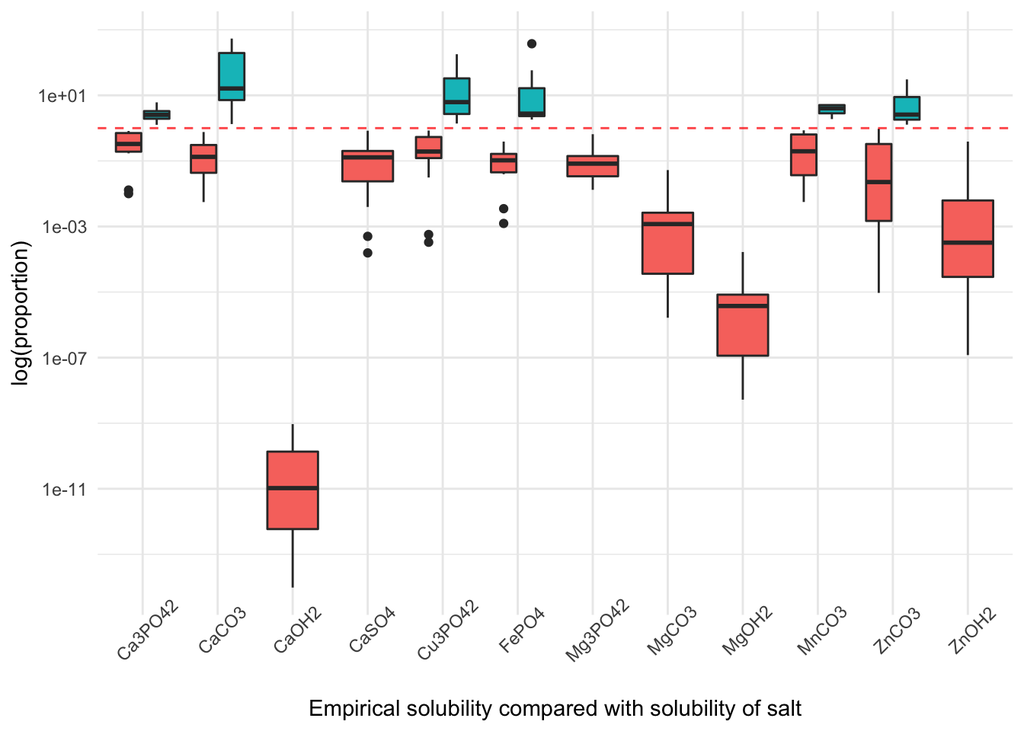

```r
plotdata %>%
  #filter(proportion < 2) %>%
  mutate(
    substance = as.factor(substance),
    treshold_label = if_else(proportion > 1, true = '2', false = '1')
    ) %>%
  ggplot(aes(
    x = substance,
    y = proportion,
    fill = treshold_label
    )) +
    geom_boxplot() +
    geom_hline(yintercept = 1, linetype = 'dashed', color = 'red', alpha = 0.75) +
    scale_y_log10() +
    #facet_wrap(facets = vars(substance), scales = 'free') +
    labs(
      x = 'Empirical solubility compared with solubility of salt',
      y = 'log(proportion)'
    ) +
    theme_minimal() +
    theme(
      axis.text.x = element_text(angle = 45),
      legend.position = 'none'
      )
```

The results can be explained as follows:

*Carbonates:* It appears as the concentration of calcium is much higher than possible if carbonates were limiting the concentration in the system. This is true for CaCO3, MnCO3 and ZnCO3. However, it was assumed that the water is in equilibrium with atmospheric CO2, which is oftentimes not the case in aquaculture systems. Instead, the water is degassed. Currently, the assumed concentration of CO2 in water is [CO2(aq)] $\approx$ 70 mg/L. According to Terjesen et al. (2013), a more realistic value would be 5 mg/L. Thus, in the second iteration, the CO2 concentration will be reduced.

*Phosphates:* The concentration of Ca, Fe and Cu is higher than theoretically possible if precipitation of phosphates was the concentration limiting factor. With respect to **Fe** and **Cu**, the reason for the comparably higher values could be the formation of complex molecules. Complexation can lead to a concentration increase of the affected metals by approximately three orders of magnitude, depending on the stability of the resulting complex. With respect to **Ca**, the reason for the elevated concentrations might be interactions with humic matter.

# 3. pH-correction - 2nd iteration

As mentioned, the concentration of CO2 will be reduced in this iteration by reducing the assumed partial pressure of CO2 from 0.054 to 0.0027 atm. This results in a decrease of the CO2 concentrtion in water by factor 20. All concentrations are initially reported in mg/L.

```r
procdata <- empirical_data %>%

  # Rename columns
  rename('NH4-N' = 'N.NH4_mgL', 'NO2-N' = 'N.NO2_mgL', 'NO3-N' = 'N.NO3_mgL', 'PO4-P' = 'P.PO4_mgL', 'K' = 'K_mgL', 'Ca' = 'Ca_mgL', 'Mg' = 'Mg_mgL', 'SO4-S' = 'S.SO4_mgL', 'B' = 'B_mgL', 'Fe' = 'Fe_mgL', 'Mn' = 'Mn_mgL', 'Cu' = 'Cu_mgL', 'Zn' = 'Zn_mgL', 'Na' = 'Na_mgL', 'Mo' = 'Mo_mgL', 'Ni' = 'Ni_mgL') %>%

  select(-ends_with(c('const', 'belowLimit'))) %>%

  # Replace NAs by 0
  mutate_at(vars(`NH4-N`, `NO2-N`, `NO3-N`), tidyr::replace_na, 0) %>%

  mutate(
    # Calculate Total Inorganic Nitrogen by summing NH4, NO2 and NO3
    TIN = `NH4-N` + `NO2-N` + `NO3-N`,
    # Calculate [PO4]
    species_PO4_molL = calc_PO4(c_tot = `PO4-P`, pH = pH, form_P = "PO4-P", unit = "mg"),
    # Calculate [CO3]
    species_CO3_molL = calc_CO3(pH = pH, pCO2 = 0.0027),
    # Calculate [OH]
    species_OH_molL = calc_OH(pH = pH),
    # Calculate [SO4]
    species_SO4_molL = calc_SO4(c_tot = `SO4-S`, pH = pH, form_S = "SO4-S", unit = "mg")
    ) %>%
  print()
```

```
##      Reference_ID   Treatment_ID Include     source condition  days   pH
## 1   Blanchard2020            pH5     Yes waterTRANS   aerobic    NA 6.30
## 2   Blanchard2020          pH5.8     Yes waterTRANS   aerobic    NA 6.40
## 3   Blanchard2020          pH6.5     Yes waterTRANS   aerobic    NA 6.70
## 4   Blanchard2020            pH7     Yes waterTRANS   aerobic    NA 6.90
## 5      Cerozi2020         System     Yes waterTRANS   aerobic    NA 6.55
## 6     Delaide2018            AER     Yes waterREMIN   aerobic  42.0 6.54
## 7     Delaide2018            ANR     Yes waterREMIN anaerobic  42.0 6.65
## 8     Delaide2019             AP     Yes   waterRAS   aerobic    NA 7.85
## 9     Delaide2021             AE     Yes waterREMIN   aerobic  45.0 6.80
## 10     Goddek2016            AER     Yes waterREMIN   aerobic  35.0 8.40
## 11     Goddek2016            ANA     Yes waterREMIN anaerobic  35.0 8.50
## 12     Goddek2018 Uliege_aerobic     Yes waterREMIN   aerobic  40.0 7.20
## 13     Goddek2018            pH+     Yes waterREMIN anaerobic  40.0 7.40
## 14     Goddek2018            pH-     Yes waterREMIN anaerobic  40.0 7.40
```

[output cut: 225 more lines]

```r
# Read molar weight data
molarWeight <- read.csv2(file = 'data/molarWeight.csv')

#
procdata <- procdata %>%

  rename('S' = 'SO4-S', 'N' = 'TIN') %>%

  pivot_longer( # Convert into longtable
    cols = K:N,
    names_to = 'nutrient',
    values_to = 'concentration_mgL'
    ) %>%
  left_join(molarWeight, by = c('nutrient' = 'element')) %>%

  mutate(
    g_per_mol = as.numeric(g_per_mol), # Convert from character into numeric
    concentration_molL = concentration_mgL/(1e3 * g_per_mol) # Convert from mg/L into mol/L
    ) %>%

  select(-c(concentration_mgL, g_per_mol)) %>% # Remove unnecessary columns

  pivot_wider( # Convert into widetable
    names_from = 'nutrient',
    values_from = 'concentration_molL'
    ) %>%

  print()
```

```
## # A tibble: 47 × 30
##    Reference_ID  Treatment_ID Include source     condition  days    pH temp_degC
##    <chr>         <chr>        <chr>   <chr>      <chr>     <dbl> <dbl>     <dbl>
##  1 Blanchard2020 pH5          Yes     waterTRANS aerobic      NA  6.3       NA
##  2 Blanchard2020 pH5.8        Yes     waterTRANS aerobic      NA  6.4       NA
##  3 Blanchard2020 pH6.5        Yes     waterTRANS aerobic      NA  6.7       NA
##  4 Blanchard2020 pH7          Yes     waterTRANS aerobic      NA  6.9       NA
##  5 Cerozi2020    System       Yes     waterTRANS aerobic      NA  6.55      NA
##  6 Delaide2018   AER          Yes     waterREMIN aerobic      42  6.54      28
##  7 Delaide2018   ANR          Yes     waterREMIN anaerobic    42  6.65      28
##  8 Delaide2019   AP           Yes     waterRAS   aerobic      NA  7.85      NA
##  9 Delaide2021   AE           Yes     waterREMIN aerobic      45  6.8       20.5
## 10 Goddek2016    AER          Yes     waterREMIN aerobic      35  8.4       22.9
## # … with 37 more rows, and 22 more variables: EC_uScm <dbl>, NH4-N <dbl>,
## #   NO2-N <dbl>, NO3-N <dbl>, PO4-P <dbl>, species_PO4_molL <dbl>,
## #   species_CO3_molL <dbl>, species_OH_molL <dbl>, species_SO4_molL <dbl>,
## #   K <dbl>, Ca <dbl>, Mg <dbl>, S <dbl>, B <dbl>, Fe <dbl>, Mn <dbl>,
## #   Cu <dbl>, Zn <dbl>, Mo <dbl>, Ni <dbl>, Na <dbl>, N <dbl>
```

```r
procdata <- procdata %>%
  mutate(
    # CaCO3
    Ca_in_CaCO3 = solubility_data$Ks0[which(solubility_data$chemFormula == "CaCO3",)] / species_CO3_molL,
    Ca_found_greater_CaCO3 = Ca > Ca_in_CaCO3,
    CaCO3_diff = Ca - Ca_in_CaCO3,
    CaCO3_prop = Ca / Ca_in_CaCO3,

    # Ca(OH)2
    Ca_in_CaOH2 = solubility_data$Ks0[which(solubility_data$chemFormula == "Ca(OH)2",)] / species_OH_molL^2,
    Ca_found_greater_CaOH2 = Ca > Ca_in_CaOH2,
    CaOH2_diff = Ca - Ca_in_CaOH2,
    CaOH2_prop = Ca / Ca_in_CaOH2,

    # Ca3PO42
    Ca_in_Ca3PO42 = (solubility_data$Ks0[which(solubility_data$chemFormula == "Ca3(PO4)2",)] / species_PO4_molL^2)^(1/3),
    Ca_found_greater_Ca3PO42 = Ca > Ca_in_Ca3PO42,
    Ca3PO42_diff = Ca - Ca_in_Ca3PO42,
    Ca3PO42_prop = Ca / Ca_in_Ca3PO42,


    # CaSO4
    Ca_in_CaSO4 = solubility_data$Ks0[which(solubility_data$chemFormula == "CaSO4",)] / species_SO4_molL,
    Ca_found_greater_CaSO4 = Ca > Ca_in_CaSO4,
    CaSO4_diff = Ca - Ca_in_CaSO4,
    CaSO4_prop = Ca / Ca_in_CaSO4,

    # MgCO3
    Mg_in_MgCO3 = solubility_data$Ks0[which(solubility_data$chemFormula == "MgCO3",)] / species_CO3_molL,
    Mg_found_greater_MgCO3 = Mg > Mg_in_MgCO3,
    MgCO3_diff = Mg - Mg_in_MgCO3,
    MgCO3_prop = Mg / Mg_in_MgCO3,

    # Mg(OH)2
    Mg_in_MgOH2 = solubility_data$Ks0[which(solubility_data$chemFormula == "Mg(OH)2",)] / species_OH_molL^2,
    Mg_found_greater_MgOH2 = Mg > Mg_in_MgOH2,
    MgOH2_diff = Mg - Mg_in_MgOH2,
    MgOH2_prop = Mg / Mg_in_MgOH2,


    # Mg3PO42
    Mg_in_Mg3PO42 = (solubility_data$Ks0[which(solubility_data$chemFormula == "Mg3(PO4)2",)] / species_PO4_molL^2)^(1/3),
    Mg_found_greater_Mg3PO42 = Mg > Mg_in_Mg3PO42,
    Mg3PO42_diff = Mg - Mg_in_Mg3PO42,
    Mg3PO42_prop = Mg / Mg_in_Mg3PO42,

    # FePO4
    Fe_in_FePO4 = solubility_data$Ks0[which(solubility_data$chemFormula == "FePO4 x 2 H2O",)] / species_PO4_molL,
    Fe_found_greater_FePO4 = Fe > Fe_in_FePO4,
    FePO4_diff = Fe - Fe_in_FePO4,
    FePO4_prop = Fe / Fe_in_FePO4,

    # MnCO3
    Mn_in_MnCO3 = solubility_data$Ks0[which(solubility_data$chemFormula == "MnCO3",)] / species_CO3_molL,
    Mn_found_greater_MnCO3 = Mn > Mn_in_MnCO3,
    MnCO3_diff = Mn - Mn_in_MnCO3,
    MnCO3_prop = Mn / Mn_in_MnCO3,

    # Cu3PO42
    Cu_in_Cu3PO42 = (solubility_data$Ks0[which(solubility_data$chemFormula == "Cu3(PO4)2",)] / species_PO4_molL^2)^(1/3),
    Cu_found_greater_Cu3PO42 = Cu > Cu_in_Cu3PO42,
    Cu3PO42_diff = Cu - Cu_in_Cu3PO42,
    Cu3PO42_prop = Cu / Cu_in_Cu3PO42,

    # ZnCO3
    Zn_in_ZnCO3 = solubility_data$Ks0[which(solubility_data$chemFormula == "ZnCO3",)] / species_CO3_molL,
    Zn_found_greater_ZnCO3 = Zn > Zn_in_ZnCO3,
    ZnCO3_diff = Zn - Zn_in_ZnCO3,
    ZnCO3_prop = Zn / Zn_in_ZnCO3,

    # Zn(OH)2
    Zn_in_ZnOH2 = solubility_data$Ks0[which(solubility_data$chemFormula == "Zn(OH)2",)] / species_OH_molL^2,
    Zn_found_greater_ZnOH2 = Zn > Zn_in_ZnOH2,
    ZnOH2_diff = Zn - Zn_in_ZnOH2,
    ZnOH2_prop = Zn / Zn_in_ZnOH2,

    # NiCO3
    Ni_in_NiCO3 = solubility_data$Ks0[which(solubility_data$chemFormula == "NiCO3",)] / species_CO3_molL,
    Ni_found_greater_NiCO3 = Ni > Ni_in_NiCO3,
    NiCO3_diff = Ni - Ni_in_NiCO3,
    NiCO3_prop = Ni / Ni_in_NiCO3,

    # Ni(OH)2
    Ni_in_NiOH2 = solubility_data$Ks0[which(solubility_data$chemFormula == "Ni(OH)2",)] / species_OH_molL^2,
    Ni_found_greater_NiOH2 = Ni > Ni_in_NiOH2,
    NiOH2_diff = Ni - Ni_in_NiOH2,
    NiOH2_prop = Ni / Ni_in_NiOH2,

    # Ni3PO42
    Ni_in_Ni3PO42 = (solubility_data$Ks0[which(solubility_data$chemFormula == "Ni3(PO4)2",)] / species_PO4_molL^2)^(1/3),
    Ni_found_greater_Ni3PO42 = Ni > Ni_in_Ni3PO42,
    Ni3PO42_diff = Ni - Ni_in_Ni3PO42,
    Ni3PO42_prop = Ni / Ni_in_Ni3PO42
  ) %>%
  print()
```

```
## # A tibble: 47 × 90
##    Reference_ID  Treatment_ID Include source     condition  days    pH temp_degC
##    <chr>         <chr>        <chr>   <chr>      <chr>     <dbl> <dbl>     <dbl>
##  1 Blanchard2020 pH5          Yes     waterTRANS aerobic      NA  6.3       NA
##  2 Blanchard2020 pH5.8        Yes     waterTRANS aerobic      NA  6.4       NA
##  3 Blanchard2020 pH6.5        Yes     waterTRANS aerobic      NA  6.7       NA
##  4 Blanchard2020 pH7          Yes     waterTRANS aerobic      NA  6.9       NA
##  5 Cerozi2020    System       Yes     waterTRANS aerobic      NA  6.55      NA
##  6 Delaide2018   AER          Yes     waterREMIN aerobic      42  6.54      28
##  7 Delaide2018   ANR          Yes     waterREMIN anaerobic    42  6.65      28
##  8 Delaide2019   AP           Yes     waterRAS   aerobic      NA  7.85      NA
##  9 Delaide2021   AE           Yes     waterREMIN aerobic      45  6.8       20.5
## 10 Goddek2016    AER          Yes     waterREMIN aerobic      35  8.4       22.9
## # … with 37 more rows, and 82 more variables: EC_uScm <dbl>, NH4-N <dbl>,
## #   NO2-N <dbl>, NO3-N <dbl>, PO4-P <dbl>, species_PO4_molL <dbl>,
## #   species_CO3_molL <dbl>, species_OH_molL <dbl>, species_SO4_molL <dbl>,
## #   K <dbl>, Ca <dbl>, Mg <dbl>, S <dbl>, B <dbl>, Fe <dbl>, Mn <dbl>,
## #   Cu <dbl>, Zn <dbl>, Mo <dbl>, Ni <dbl>, Na <dbl>, N <dbl>,
## #   Ca_in_CaCO3 <dbl>, Ca_found_greater_CaCO3 <lgl>, CaCO3_diff <dbl>,
## #   CaCO3_prop <dbl>, Ca_in_CaOH2 <dbl>, Ca_found_greater_CaOH2 <lgl>, …
```

The following compounds were not considered:

```r
procdata %>%
  select(Ca_in_CaCO3:Ni_in_Ni3PO42) %>%
  print()
```

```
## # A tibble: 47 × 57
##    Ca_in_CaCO3 Ca_found_greater_CaCO3 CaCO3_diff CaCO3_prop  Ca_in_CaOH2
##          <dbl> <lgl>                       <dbl>      <dbl>        <dbl>
##  1   0.440     FALSE                   -0.435       0.0106  12609669886.
##  2   0.278     FALSE                   -0.273       0.0169   7956163826.
##  3   0.0697    FALSE                   -0.0651      0.0665   1998497996.
##  4   0.0278    FALSE                   -0.0231      0.168     795616383.
##  5   0.139     FALSE                   -0.138       0.0114   3987527738.
##  6   0.146     NA                      NA          NA        4175454131.
##  7   0.0878    NA                      NA          NA        2515959913.
##  8   0.000350  TRUE                     0.00322    10.2        10016217.
##  9   0.0440    FALSE                   -0.0438      0.00417  1260966989.
## 10   0.0000278 TRUE                     0.000272   10.8          795616.
## # … with 37 more rows, and 52 more variables: Ca_found_greater_CaOH2 <lgl>,
## #   CaOH2_diff <dbl>, CaOH2_prop <dbl>, Ca_in_Ca3PO42 <dbl>,
## #   Ca_found_greater_Ca3PO42 <lgl>, Ca3PO42_diff <dbl>, Ca3PO42_prop <dbl>,
## #   Ca_in_CaSO4 <dbl>, Ca_found_greater_CaSO4 <lgl>, CaSO4_diff <dbl>,
## #   CaSO4_prop <dbl>, Mg_in_MgCO3 <dbl>, Mg_found_greater_MgCO3 <lgl>,
## #   MgCO3_diff <dbl>, MgCO3_prop <dbl>, Mg_in_MgOH2 <dbl>,
## #   Mg_found_greater_MgOH2 <lgl>, MgOH2_diff <dbl>, MgOH2_prop <dbl>, …
```

**Are empirical values above the calculated solubilities?**

[output not shown]

## 3.3 Plot data

### 3.3.1 Create expectation_data

```r
#procdata %>%
```

### 3.3.2 Create plotdata

```r
plotdata <- procdata %>%
  select(ends_with('_prop')) %>%
  pivot_longer(
    cols = everything(),
    names_to = 'substance',
    values_to = 'proportion'
  ) %>%
  mutate(
    substance = sub('_prop', '', substance)
  ) %>%
  filter(
    proportion != Inf
    ) %>%
  print()
```

```
## # A tibble: 309 × 2
##    substance proportion
##    <chr>          <dbl>
##  1 CaCO3       1.06e- 2
##  2 CaOH2       3.70e-13
##  3 Ca3PO42     6.91e- 1
##  4 MgCO3       9.21e- 7
##  5 MgOH2       5.84e- 8
##  6 Mg3PO42     2.59e- 2
##  7 FePO4       1.63e- 1
##  8 MnCO3       3.10e- 4
##  9 Cu3PO42     1.93e- 1
## 10 ZnCO3       6.40e- 5
## # … with 299 more rows
```

### 3.3.3 Create plot

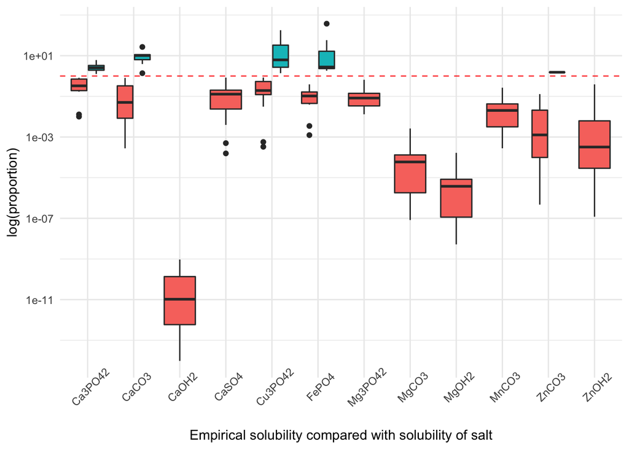

```r
plotdata %>%
  #filter(proportion < 2) %>%
  mutate(
    substance = as.factor(substance),
    treshold_label = if_else(proportion > 1, true = '2', false = '1')
    ) %>%
  ggplot(aes(
    x = substance,
    y = proportion,
    fill = treshold_label
    )) +
    geom_boxplot() +
    geom_hline(yintercept = 1, linetype = 'dashed', color = 'red', alpha = 0.75) +
    scale_y_log10() +
    #facet_wrap(facets = vars(substance), scales = 'free') +
    labs(
      x = 'Empirical solubility compared with solubility of salt',
      y = 'log(proportion)'
    ) +
    theme_minimal() +
    theme(
      axis.text.x = element_text(angle = 45),
      legend.position = 'none'
      )
```

Now life is much better! *Carbonates:* Even though the concentrations for CaCO3 and ZnCO3 are still above the theoretical values, this can again be a matter of low CO2 concentrations in the systems, for instance as a result of low stocking densities. The value of 5 mg/L of CO2 was reported for a system with a stocking density of 25 kg/m3. Considering that supernatants from aerobic digesters are part of the dataset as well, it might still be the case that the carbonate concentration is overestimated.